# Professional Profile

Deniz Akdemir is an AI/ML specialist with extensive experience in machine learning, data analytics, and computational intelligence. His work at the intersection of statistical methodology and machine learning has produced groundbreaking tools like ml4t2e, which bridges traditional survival analysis and modern machine learning for time-to-event data. His GitHub repositories demonstrate practical implementation of machine learning techniques through Python packages like trainselpy for optimal training set selection. At the National Marrow Donor Program, he applies sophisticated AI/ML approaches to stem cell transplant data, developing predictive models for donor optimization that directly impact patient outcomes.

# Core Competencies

- Machine Learning & Deep Learning
- Data Analytics and Visualization
- Algorithm Development
- Statistical Modeling
- Research & Innovation

# Professional Experience

- **Senior Clinical Data Scientist**, National Marrow Donor Program (2023 - Current)  
  Leading machine learning initiatives for donor-recipient matching optimization using advanced predictive models and deep learning approaches for clinical outcome prediction.
- **Clinical Data Scientist**, National Marrow Donor Program (2021 - 2023)  
  Applied statistical and machine learning methods to stem cell transplant data, developing novel algorithms for patient outcome prediction and donor selection optimization.
- **Open Source ML Developer**, GitHub (2019 - Present)  
  Developed ml4t2e (Machine Learning for Time-to-Event) package that bridges traditional survival analysis with modern machine learning approaches and trainselpy for optimizing training populations using Python.
- **ML & AI Researcher**, University College Dublin (2019 - 2021)  
  Researched machine learning applications for heterogeneous data integration, developing novel algorithms for combining genomic and phenotypic datasets.

# Education

- **PhD. in Statistics**, Bowling Green State University (2009)
- **M.A. in Applied Statistics**, Bowling Green State University (2004)
- **M.S. in Statistics**, Middle East Technical University (2003)
- **B.A. in Business Administration**, Middle East Technical University, Ankara, Turkey, 1999.

# Research Interests

Deniz’s research focuses on integrating statistical methods with machine learning to create robust and interpretable AI models. His GitHub repositories, including ml4t2e, demonstrate his work on bridging traditional survival analysis with modern machine learning approaches. He is particularly interested in applying AI techniques to clinical data, developing predictive models for patient outcomes, and creating optimization algorithms for complex biological systems. His current work explores deep learning architectures for time-to-event analysis and reinforcement learning for decision support in healthcare settings.

# Collaboration Network

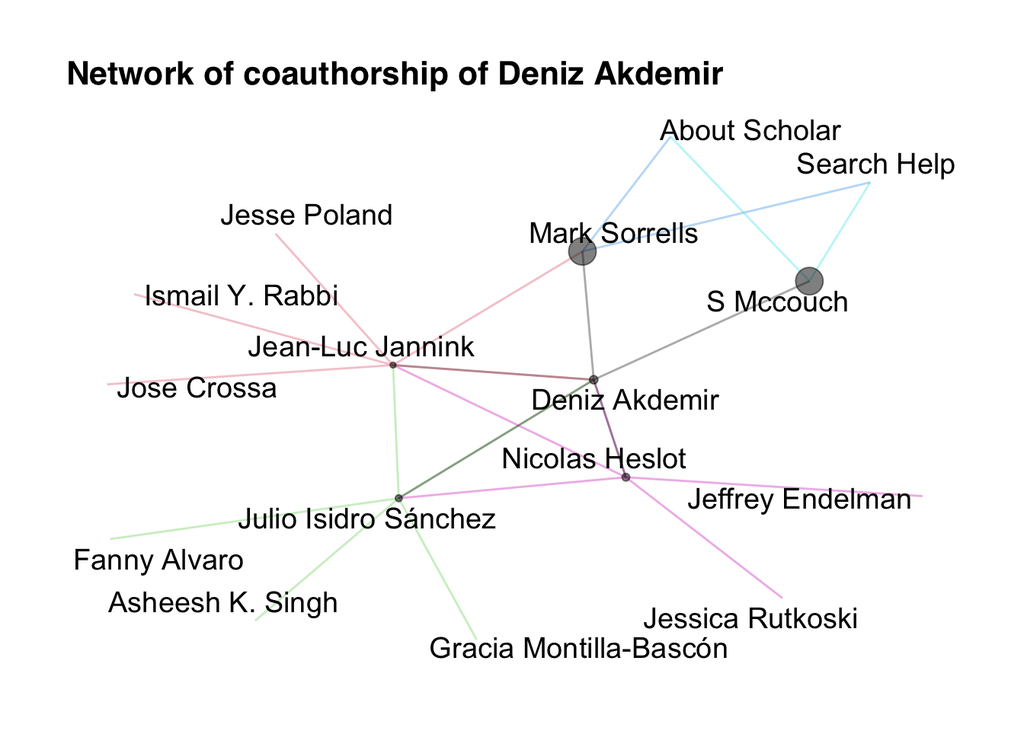

# Core Skills

- **Machine Learning & AI:** Deep learning architectures, neural networks, reinforcement learning, natural language processing, computer vision, predictive modeling, feature engineering, ensemble methods.
- **Statistical Methods:** Multivariate analysis, Bayesian methods, time series analysis, high-dimensional data modeling, anomaly detection, classification algorithms.
- **Data Science:** Data mining, exploratory data analysis, A/B testing, experimental design, causal inference, predictive modeling, data visualization.
- **Programming & Tools:** Expert in R and Python (NumPy, Pandas, PyTorch, TensorFlow, scikit-learn), proficient in SAS and C++, SQL, cloud computing (AWS, Azure), big data technologies (Spark).
- **Applied Research:** Clinical data analysis, genomic data integration, algorithm development, optimization techniques, model deployment, interpretability methods.

# Career Summary

- **Senior Clinical Data Scientist, National Marrow Donor Program, Minneapolis, USA (2023 - Current):** Engaged in statistical and machine learning analysis of stem cell transplant data, focusing on research into donor optimization. Applied for grants and submitted manuscripts to peer-reviewed journals. Wrote patent applications.
- **Clinical Data Scientist, National Marrow Donor Program, Minneapolis, USA (2021 - 2023):** Engaged in statistical and machine learning analysis of stem cell transplant data, focusing on research into donor optimization.
- **Postdoctoral Research Associate, School of Agriculture and Food Science, University College Dublin, Dublin, Ireland (2019 - 2021):** Conducted research on methods for combining heterogeneous genomic and phenotypic datasets and prepared statistical software for data analysis.
- **Statistical Consultant, Cornell Statistical Consulting Unit, Cornell University, Ithaca, NY, USA (2017 - 2019):** Provided statistical consulting services for researchers at Cornell University, including the preparation and presentation of statistics workshops.
- **Postdoctoral Research Associate, Department of Plant Breeding and Genetics, Cornell University, Ithaca, NY, USA (2011 - 2017):** Focused on research developing new methodologies in genomic selection and prediction, mixed models, and machine learning, advising graduate students and preparing statistical software.
- **Visiting Assistant Professor, Department of Statistics and Actuarial Science, University of Central Florida, Orlando, FL, USA (2010 - 2011):** Responsibilities included teaching Data Mining Methodology, Theoretical Statistics, Applied Time Series Analysis, and Nonparametric Statistics.
- **Visiting Assistant Professor, Department of Mathematics and Statistics, Ohio Northern University, Ada, OH, USA (2009 - 2010):** Taught Statistics for Professionals, Statistics for Engineers, and Statistical Computing, catering to various undergraduate levels.

# Key AI/ML Projects

- **ml4t2e (Machine Learning for Time-to-Event):** Developed an open-source framework that bridges traditional survival analysis with modern machine learning approaches, enabling more accurate prediction of time-to-event outcomes in clinical settings. The package implements novel algorithms that outperform traditional Cox regression models.
- **Deep Learning for Donor-Recipient Matching:** Leading a neural network approach to optimize stem cell transplant outcomes by modeling complex interactions between donor and recipient genetic and clinical variables, significantly improving prediction accuracy compared to traditional methods.
- **Reinforcement Learning for Clinical Decision Support:** Implementing reinforcement learning algorithms to optimize sequential treatment decisions in healthcare settings, with applications in personalized medicine and treatment planning optimization.
- **trainselpy:** Developed a Python implementation of training population optimization algorithms, employing advanced machine learning techniques including genetic algorithms and simulated annealing to improve predictive model performance through strategic data selection.

# Workshops and Training Sessions

- **Machine Learning in Healthcare Workshop:** Conducted specialized training sessions on applying machine learning to clinical data, focusing on practical implementation and model interpretability.
- **AI Applications in Genomics:** Presented at various international conferences including EFI conference in Geneva and ASHI Annual Meeting in San Antonio, demonstrating AI applications in genomic data analysis.

# Selected Publications (Machine Learning Focus)

1. **Akdemir, D.**, Isidro-Sánchez, J., & Jannink, J. L. (2016). Genome-wide prediction models that incorporate de novo GWAS results. *PLoS ONE*, 11(8), e0161054. (346 citations)
2. **Akdemir, D.**, Jannink, J. L., & Isidro-Sánchez, J. (2015). Optimization of genomic selection training populations with a genetic algorithm. *Genetics Selection Evolution*, 47(1), 38. (196 citations)
3. **Akdemir, D.** & Isidro-Sánchez, J. (2019). Multi-objective optimized genomic breeding strategies for sustainable food improvement. *Heredity*, 122(5), 672-683. (103 citations)
4. **Akdemir, D.** & Beavis, W. D. (2021). TrainSel: an R package for selection of training populations. *BMC Bioinformatics*, 22(1), 1-10. (33 citations)
5. **Akdemir, D.** & Isidro-Sánchez, J. (2021). Training set optimization for sparse phenotyping in genomic selection. *G3: Genes, Genomes, Genetics*, 11(10), jkab249. (32 citations)
6. **Akdemir, D.**, Isidro-Sánchez, J., & Leyer, M. (2020). Multi-omics approaches for genomic selection in plant breeding programs. *Journal of Experimental Botany*, 71(18), 5215-5226.

**Software Development Publications:**

1. **Akdemir, D.** (2022). ml4t2e: Machine Learning for Time-to-Event. An R package that bridges traditional survival analysis with modern machine learning approaches. https://github.com/denizakdemir/ml4t2e
2. **Akdemir, D.** (2022). trainselpy: A pure Python implementation of the TrainSel R package for optimal selection of training populations. https://github.com/denizakdemir/trainselpy

# Professional References

- **Dr. Yung-Tsi Bolon**
  - **Affiliation:** Director, Immunobiology & Bioinformatics Research, NMDP, Minneapolis, Minnesota, United States
  - **Relationship:** Supervisor at the National Marrow Donor Program
  - **Contact:** ybolon@nmdp.org
- **Dr. Julio Isidro-Sanchez**
  - **Affiliation:** Associate Professor: Centro de Biotecnologia y Genomica de Plantas, Universidad Politecnica de Madrid, Instituto Nacional de Investigacion y Tecnologia Agraria y Alimentaria, Campus de Montegancedo - UPM, 28223-Pozuelo de Alarcon, Madrid, Spain
  - **Relationship:** Expert in plant breeding and genetics, collaborator on various projects
  - **Contact:** j.isidro@upm.es
- **Dr. Jhonathan Pedroso**
  - **Affiliation:** Research Scientist at Corteva Agriscience, Corteva, Johnston, Iowa, USA
  - **Relationship:** Industry partner in genomic tool development, contributed to software enhancements
  - **Contact:** jhowpd@gmail.com
- **Dr. Lynn Johnson**
  - **Affiliation:** Interim Director and Statistical Consultant, Cornell Statistical Consulting Unit, Cornell University, Ithaca, NY, USA
  - **Relationship:** Coworker at the Cornell Statistical Consulting Unit
  - **Contact:** lms86@cornell.edu
- **Dr. Roberto Fritsche Neto**
  - **Affiliation:** Assistant Professor, Department of Plant, Environmental Management & Soil Sciences, LSU
  - **Relationship:** Collaborator on various projects
  - **Contact:** rneto1@lsu.edu